# Yeast TFBS Analysis Report

Emmanuel Cazottes

28 January, 2026

Analyse the TFBS content of yeast selected sequences, AL pool sequences, Top/Bottom 1% selected sequences and randomly selected sequences.

This notebook take as input the `fimo.tsv` file obtained by doing motif scanning with FIMO with the JASPAR as TF motifs database and thresdholding on FDR 0.01. The custom background passed to FIMO, was generated using nucleotide frequencies derived from the AL pool sequences using the `fasta-get-markov` tool from the MEME suite. TFBS scanning with FIMO is only done on the AL pool for filtering consistency.

Filtering for Yeast TF using the sarCer3 reference annotation.

# Data import and preprocessing

Reference annotation to select for Yeast TFs.

```r
# Load gene annotation to remove the non-Yeast TF
yeast.gtf = read.table("reference/sacCer3.ncbiRefSeq.gtf.gz", header = F, sep = "\t")
yeast.genes = unlist(lapply(str_split(yeast.gtf$V9, " "), function(x){x[length(x)]}))
yeast.genes = unique(gsub(";","", yeast.genes))
```

TFBS scanning done on 17 equivalent chunks of the yeast AL pool because demanded too much ressources

```r
fimo.files = list.files("sequence_analysis/FIMO_ALpool_jaspar/", pattern = "fimo.tsv",recursive = T, full.names = T)
fimo.al=lapply(fimo.files, function(x){
  df = read.table(x, header=T,sep = "\t")
  df = subset(df, motif_alt_id %in% yeast.genes) #Keep only yeast TFs
  df = df[,-c(2,4,5,6,7,8,9,10)] #Remove the columns with info I won't be using for now
  df$method = unlist(lapply(str_split(df$sequence_name, "\\|"), function(x){x[2]})) # Get the method name
  df$sequence_name = unlist(lapply(str_split(df$sequence_name, "\\|"), function(x){x[1]})) # Get the SeqID
  return(df)
})

fimo.al = do.call("rbind",fimo.al)
```

Function to import the fimo.tsv file containing the TFBS for each selected sequences and the original sequence file to recover the sequences without TFBS.

```r
preprocess.tf = function(data.tf, path.seq){
  if (is.data.frame(data.tf)) {
      seq = read.table(path.seq, header = F, sep = "\t", col.names = c("sequence_name", "sequence", "method"))
      seq = seq[,-2]
      tf.motifs = merge(seq,data.tf,by = "sequence_name",all.x = T)
      tf.motifs = tf.motifs[,-4] # REmove the duplicated method column
      colnames(tf.motifs) = c("sequence_name", "method", "motif_id")
      tf.motifs$motif_id = ifelse(is.na(tf.motifs$motif_id),0,tf.motifs$motif_id)
      return(tf.motifs)
  } else if (file.exists(data.tf)){
    tf.motifs = read.table(data.tf, header = T, sep = "\t")
    tf.motifs = subset(tf.motifs, motif_alt_id %in% yeast.genes) #Keep only yeast TFs
    tf.motifs = tf.motifs[,-c(2,4,5,6,7,8,9,10)]
    tf.motifs$method = unlist(lapply(str_split(tf.motifs$sequence_name, "\\|"), function(x){x[2]})) # Get the method name
    tf.motifs$sequence_name = unlist(lapply(str_split(tf.motifs$sequence_name, "\\|"), function(x){x[1]}))
    #Train pool sequences
    seq = read.table(path.seq, header = F, sep = "\t", col.names = c("sequence_name", "sequence", "method"))
    seq = seq[,-2]

    tf.motifs = merge(seq,tf.motifs,by = "sequence_name",all.x = T)
    tf.motifs = tf.motifs[,-4] # REmove the duplicated method column
    colnames(tf.motifs) = c("sequence_name", "method", "motif_id")
    tf.motifs$motif_id = ifelse(is.na(tf.motifs$motif_id),0,tf.motifs$motif_id)
    return(tf.motifs)
  }
}
```

```r
tf.motifs.al = preprocess.tf(fimo.al,"sequences/yeast_pool.trim.tsv")
tf.motifs.tnb = preprocess.tf(fimo.al, "sequences/yeast_top_n_bottom_1.trim.tsv")
tf.motifs.tnb$method = gsub("1x60","60k",tf.motifs.tnb$method) #homogenous naming
tf.motifs.selected = preprocess.tf(fimo.al,"sequences/master_output.tsv")
#Remove Seed information
tf.motifs.selected$method = str_remove(tf.motifs.selected$method, "(_[1-5])")
```

Some data are duplicated across pairs : RNN+CNN and All arch, let’s keep them only for the RNN

```r
tf.motifs.selected = subset(tf.motifs.selected,
                                  !(method %in% c("rnn-cnn_attn","diff_arch_attn","rnn-cnn_60k_attn","diff_arch_60k_attn","rnn-cnn_cnn","diff_arch_cnn","rnn-cnn_60k_cnn","diff_arch_60k_cnn")))
```

# Counting the number of TF motifs per sequence

Function to count the number of motifs for each TF per sequence and then the total number of motifs per sequences

```r
counts.tf = function(tf.df){
  #Counts per TF of each sequence and method
  counts.per.tf = subset(tf.df, motif_id!=0) %>%
  group_by(sequence_name,method, motif_id) %>%
  summarise(counts = n())

#Add the sequences with no TF motif found
  TF.0.counts = subset(tf.df, motif_id==0)
  TF.0.counts$counts = 0

  counts.per.tf = rbind(counts.per.tf, TF.0.counts)
#Counts of TF per sequences
  tf.per.seq = counts.per.tf %>%
    group_by(sequence_name,method) %>%
    summarise(counts = sum(counts))

  return(tf.per.seq)
}
```

```r
counts.tf.selected = counts.tf(tf.motifs.selected)
counts.tf.tnb = counts.tf(tf.motifs.tnb)
counts.tf.al = counts.tf(tf.motifs.al)
```

Randomly selected sequences from the AL pool to use as a baseline for the Cliff’s delta. 15 random sampling of 60 000 sequences.

```r
random.sampling = function(df, nb.rnd, nb.sample){
  value.list = list()
  size = seq(1, nrow(df), by=1)
  i= 1
  while (i <= nb.sample) {
    rnd.size = sample(size, nb.rnd)
    value.list[[i]] = df[rnd.size,]
    value.list[[i]]$method = paste0("RandomSampling_",i)
    i = i +1
  }
  return(value.list)
}

counts.tf.rnd = random.sampling(counts.tf.al,60000,15 )
```

# Cliff’s delta

Compute the cliff’s delta on the number of TFBS per sequence for each architecture/model pair and the AL pool. The question being do we have a different TFBS motif content (more or less TF)

## Selected sequences

Perform Cliff’s delta between the TFBS content of selected sequences to the AL pool.

```r
counts.tf.selected = counts.tf.selected %>%
  group_by(method) %>%
  group_split()

library(effectsize)
cliff.d.selected = lapply(counts.tf.selected, function(x){
  cliffs_delta(x$counts, counts.tf.al$counts)
})

cliff.d.selected = do.call("rbind", cliff.d.selected)
cliff.d.selected$method = unlist(lapply(counts.tf.selected, function(x){unique(x$method)}))
cliff.d.selected$model.arch = unlist(lapply(str_split(cliff.d.selected$method, "_"), function(x){x[length(x)]}))
cliff.d.selected$al.method = unlist(lapply(str_split(cliff.d.selected$method, "_(attn|rnn|cnn)"), function(x){x[1]}))
cliff.d.selected$model.arch = toupper(cliff.d.selected$model.arch)
```

```r
cliff.d.selected.60k = cliff.d.selected[grep(pattern = "60k", cliff.d.selected$al.method),]
cliff.d.selected.60k$model.arch = factor(cliff.d.selected.60k$model.arch, levels = c("RNN","CNN","ATTN"))
cliff.d.selected.3x20k = cliff.d.selected[grep(pattern = "60k", cliff.d.selected$al.method,invert = T),]
cliff.d.selected.3x20k$model.arch = factor(cliff.d.selected.3x20k$model.arch, levels = c("RNN","CNN","ATTN"))
cliff.d.selected.60k$al.method = cliff.d.selected.3x20k$al.method
```

## Cliff’s delta for randomly selected sequences

```r
cliff.d.rnd = lapply(counts.tf.rnd, function(x){
  cliffs_delta(x$counts, counts.tf.al$counts)
})

cliff.d.rnd = do.call("rbind", cliff.d.rnd)

cliff.d.rnd = data.frame(
  r_rank_biserial = mean(cliff.d.rnd$r_rank_biserial),
  CI=0.95,
  CI_low = min(cliff.d.rnd$r_rank_biserial),
  CI_high = max(cliff.d.rnd$r_rank_biserial),
  al.method="Random selection"
)
```

## Control sequences

```r
#To list to compute the Cliff's delta
counts.tf.SeqControl = rbind(counts.tf.tnb,counts.tf.al)
counts.tf.SeqControl = counts.tf.SeqControl %>%
  group_by(method) %>%
  group_split()
```

```r
cliff.d.controls = lapply(counts.tf.SeqControl, function(x){
  cliffs_delta(x$counts, counts.tf.al$counts)
})

cliff.d.controls = do.call("rbind", cliff.d.controls)
cliff.d.controls$al.method = unlist(lapply(counts.tf.SeqControl, function(x){unique(x$method)}))

cliff.d.controls = rbind(cliff.d.controls, cliff.d.rnd)
```

```r
cliff.d.controls.3x20k = cliff.d.controls[grep(pattern = "60k", cliff.d.controls$al.method,invert = T),]
#Rename labels for plotting
cliff.d.controls.3x20k$al.method = gsub("diversity_3x20_bottom1", "Least diverse", cliff.d.controls.3x20k$al.method)
cliff.d.controls.3x20k$al.method = gsub("diversity_3x20_top101", "Most diverse", cliff.d.controls.3x20k$al.method)
cliff.d.controls.3x20k$al.method = gsub("uncertainty_3x20_bottom1", "Least uncertain", cliff.d.controls.3x20k$al.method)
cliff.d.controls.3x20k$al.method = gsub("uncertainty_3x20_top101", "Most uncertain", cliff.d.controls.3x20k$al.method)
#Order the labels
cliff.d.controls.3x20k$al.method = factor(cliff.d.controls.3x20k$al.method,
                                levels = c("ALpool", "Random selection", "Least uncertain", "Most uncertain", "Least diverse", "Most diverse"))
```

```r
cliff.d.controls.60k = cliff.d.controls[grep(pattern = "(60k)|(ALpool)|(Random selection)", cliff.d.controls$al.method),]
cliff.d.controls.60k$al.method = gsub("diversity_60k_bottom1", "Least diverse", cliff.d.controls.60k$al.method)
cliff.d.controls.60k$al.method = gsub("diversity_60k_top101", "Most diverse", cliff.d.controls.60k$al.method)
cliff.d.controls.60k$al.method = gsub("uncertainty_60k_bottom1", "Least uncertain", cliff.d.controls.60k$al.method)
cliff.d.controls.60k$al.method = gsub("uncertainty_60k_top101", "Most uncertain", cliff.d.controls.60k$al.method)

#Order the labels
cliff.d.controls.60k$al.method = factor(cliff.d.controls.60k$al.method,
                                levels = c("ALpool", "Random selection", "Least uncertain", "Most uncertain", "Least diverse", "Most diverse"))
```

# Plots

## Selected sequences

```r
cliff.d.selected.plot.3x20k = ggplot(cliff.d.selected.3x20k, aes(al.method, y=r_rank_biserial))+
  geom_point(size=2)+
  geom_linerange(aes(ymin = CI_low, ymax = CI_high), width = 0.5, colour="black")+
  geom_hline(yintercept = c(min(cliff.d.rnd$r_rank_biserial),max(cliff.d.rnd$r_rank_biserial)),linetype=2)+
  scale_y_continuous(limits = c(-0.6, 0.6), breaks = round(seq(-0.6, 0.6, by = 0.2),2),expand = expansion(mult = 0.05))+
  facet_wrap(~model.arch, scales = "free_x")+
  theme(axis.text.x = element_text(angle = 90, vjust = 0.5, hjust=1),axis.text = element_text(size=7),plot.margin = margin(5, 5, 5, 5, "mm"))+
  labs(x="", y="Cliff's delta", title = "Yeast - 3x20")

cliff.d.selected.plot.60k = ggplot(cliff.d.selected.60k, aes(al.method, y=r_rank_biserial))+
  geom_point(size=2)+
  geom_linerange(aes(ymin = CI_low, ymax = CI_high), width = 0.5, colour="black")+
  geom_hline(yintercept = c(min(cliff.d.rnd$r_rank_biserial),max(cliff.d.rnd$r_rank_biserial)),linetype=2)+
  scale_y_continuous(limits = c(-0.6, 0.6), breaks = round(seq(-0.6, 0.6, by = 0.2),2),expand = expansion(mult = 0.05))+
  facet_wrap(~model.arch, scales = "free_x")+
  theme(axis.text.x = element_text(angle = 90, vjust = 0.5, hjust=1),axis.text = element_text(size=7),plot.margin = margin(5, 5, 5, 5, "mm"))+
  labs(x="", y="Cliff's delta",, title = "Yeast - 1x60")
```

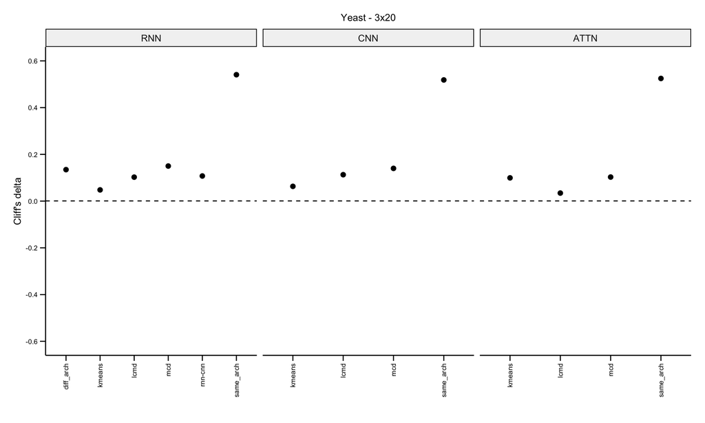

Selected sequences TFBS analysis

```r
print(cliff.d.selected.plot.3x20k)
```

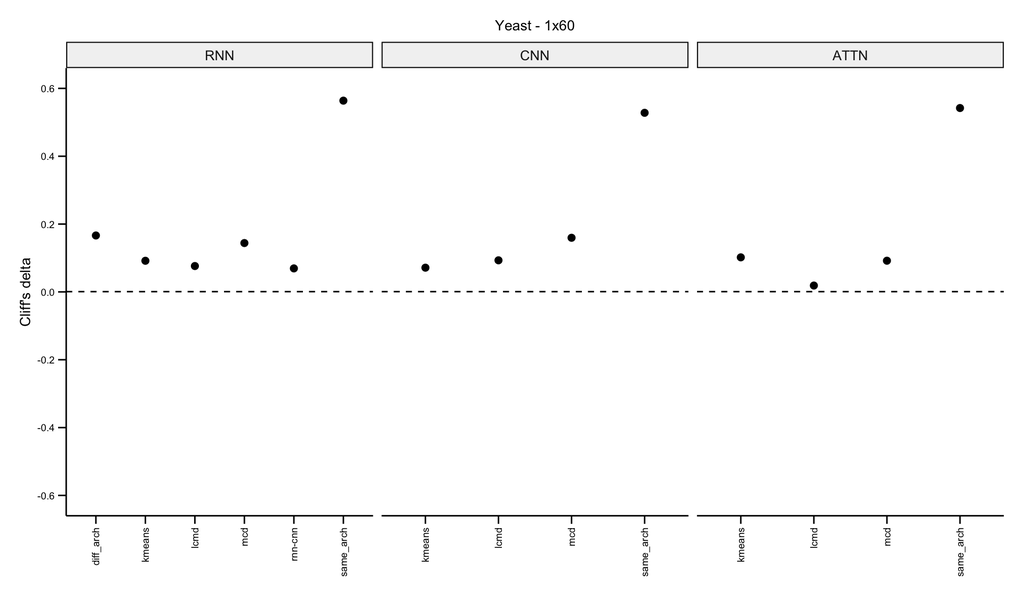

Selected sequences TFBS analysis

```r
print(cliff.d.selected.plot.60k)
```

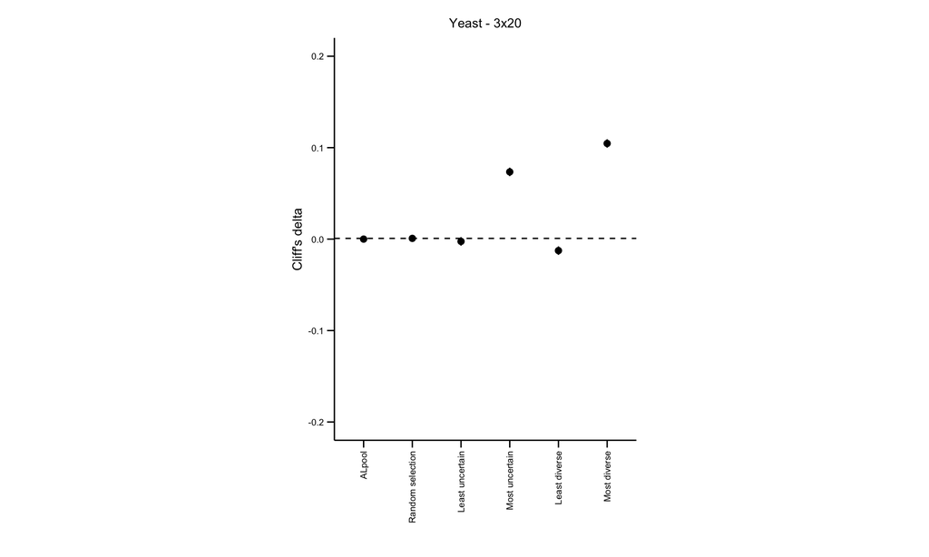

```r
cliff.d.controlSeq.3x20.plot = ggplot(cliff.d.controls.3x20k, aes(al.method, y=r_rank_biserial))+
  geom_point(size=2)+
  geom_linerange(aes(ymin = CI_low, ymax = CI_high), width = 0.5, colour="black")+
  geom_hline(yintercept = c(min(cliff.d.rnd$r_rank_biserial),max(cliff.d.rnd$r_rank_biserial)),linetype=2)+
  scale_y_continuous(limits = c(-0.2, 0.2), breaks = round(seq(-0.2, 0.2, by = 0.1),2),expand = expansion(mult = 0.05))+
  theme(axis.text.x = element_text(angle = 90, vjust = 0.5, hjust=1),
        axis.text = element_text(size=7),
        plot.margin = margin(5, 5, 5, 5, "mm"),
        aspect.ratio = c(1/0.75))+  labs(x="", y="Cliff's delta", title="Yeast - 3x20")
cliff.d.controlSeq.3x20.plot
```

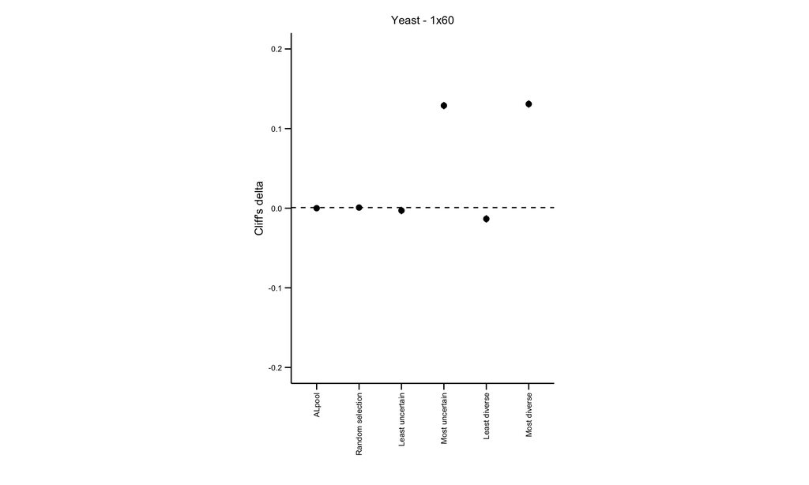

```r
cliff.d.controlSeq.60k.plot = ggplot(cliff.d.controls.60k, aes(al.method, y=r_rank_biserial))+
  geom_point(size=2)+
  geom_linerange(aes(ymin = CI_low, ymax = CI_high), width = 0.5, colour="black")+
  geom_hline(yintercept = c(min(cliff.d.rnd$r_rank_biserial),max(cliff.d.rnd$r_rank_biserial)),linetype=2)+
  scale_y_continuous(limits = c(-0.2, 0.2), breaks = round(seq(-0.2, 0.2, by = 0.1),2),expand = expansion(mult = 0.05))+
  theme(axis.text.x = element_text(angle = 90, vjust = 0.5, hjust=1),
        axis.text = element_text(size=7),
        plot.margin = margin(5, 5, 5, 5, "mm"),
        aspect.ratio = c(1/0.75))+  labs(x="", y="Cliff's delta", title="Yeast - 1x60")
cliff.d.controlSeq.60k.plot
```

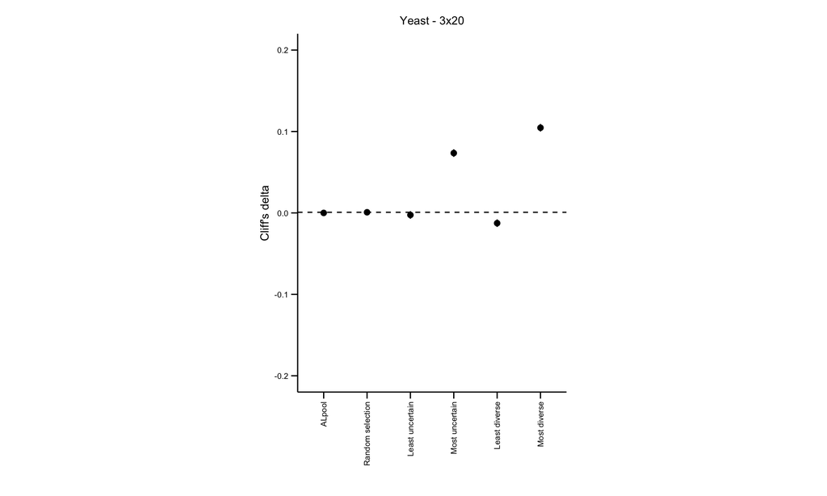

Cliff’s delta for control sequences

```r
cliff.d.controlSeq.3x20.plot
```

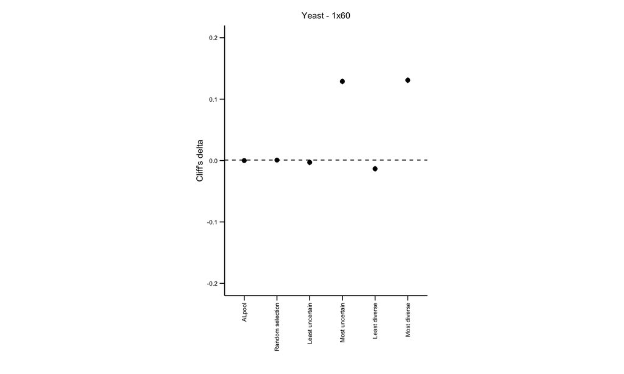

Cliff’s delta for control sequences

```r
cliff.d.controlSeq.60k.plot
```